# Higher Prelim Topic Revision - Web Version

## 15 Logs and Exponentials

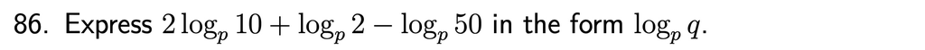

Paying attention to the *order of operations*, remember the following log laws:

Product law: $\log_{a}{x}+\log_{a}{y}=\log_{a}{xy}$

Quotient law: $\log_{a}{x}-\log_{a}{y}=\log_{a}{\left(\frac{x}{y}\right)}$

Power law: $y\log_{a}{x}=\log_{a}{x^y}$

$\log_{p}4$

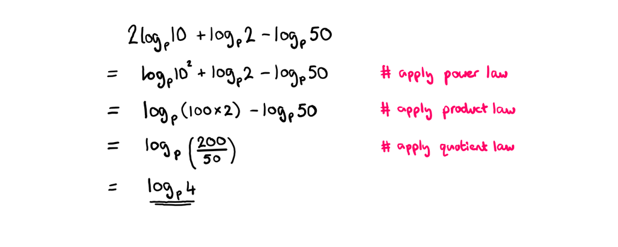

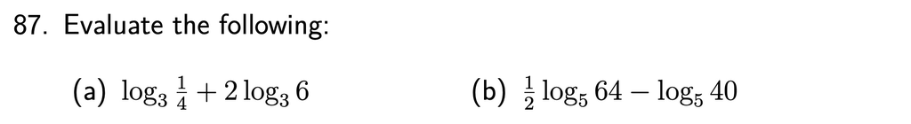

First use the laws as in the previous question before evaluating.

Remember that $\log_{a}x$ can be interpreted as $a$ to *which power* gives an answer of $x$.

1. $2$
2. $-1$

*For more practice, try:* [these past exam questions.](https://www.dynamicmaths.co.uk/QuestionBank/get_questions_handler.php?levelQ=6&otherlevellist=3&how=A&topics%5B%5D=227&orderR=dateA&calc=CN&noQ=500&minmarks=0&maxmarks=999&NR=RO&interleaved=NA&MC=MCA)

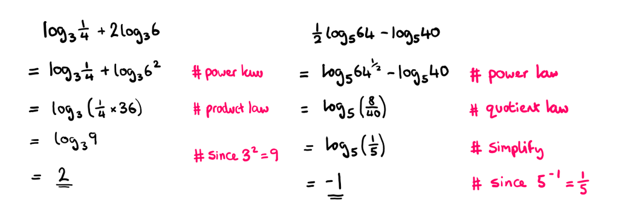

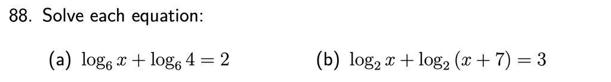

Remember that if $\log_ax=\log_ay$ then $x=y$.

To help contain each side of the equation within $\log_6$ before "cancelling", remember that $2$ can be multiplied by $log_66$ (which itself is equal to $1$).

Remember that any solutions should be checked against the original logs, since a log can only be taken of *positive numbers*.

1. $x=9$
2. $x=1$

*For more practice, try:* [results 2, 3 and 4 of these past exam questions.](https://www.dynamicmaths.co.uk/QuestionBank/get_questions_handler.php?levelQ=6&otherlevellist=3&how=A&topics%5B%5D=229&orderR=dateA&calc=CN&noQ=500&minmarks=0&maxmarks=999&NR=RO&interleaved=NA&MC=MCA)

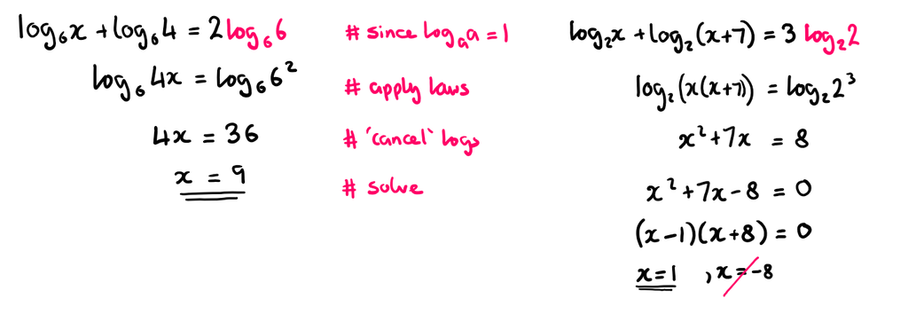

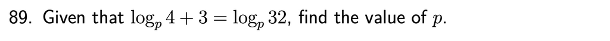

Multiplying $3$ by $\log_pp$ will help here.

$p=2$

*For more practice, try:* [results 1 and 6 of these past exam questions.](https://www.dynamicmaths.co.uk/QuestionBank/get_questions_handler.php?levelQ=6&otherlevellist=3&how=A&topics%5B%5D=229&orderR=dateA&calc=CN&noQ=500&minmarks=0&maxmarks=999&NR=RO&interleaved=NA&MC=MCA)

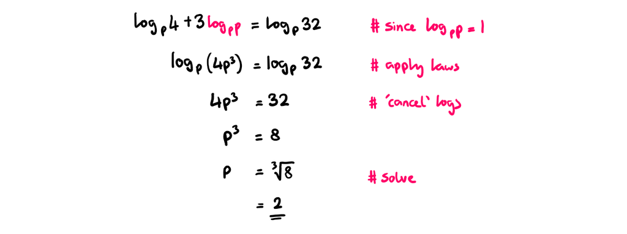

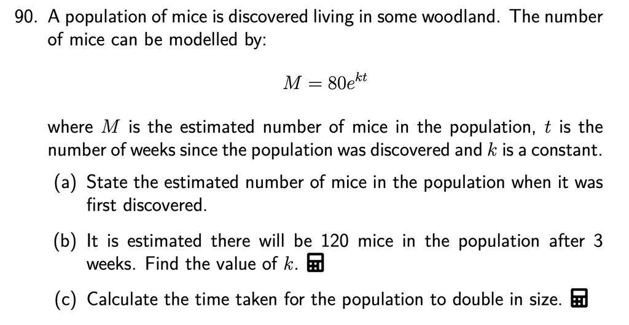

1. You may either recognised which part of $M=80e^{kt}$ is the *initial value*, or set $t=0$ and calculate.
2. Substitute the required information into the equation and solve for $k$. Remember that if $y=e^x$ then $\ln{y}=x$.
3. Since the *initial value* is $80$... The steps involved in solving for $t$ will be similar to those taken in part (b).
1. $80$
2. $k=0.135$
3. $5.13$ weeks

*For more practice, try:* [some of these past exam questions.](https://www.dynamicmaths.co.uk/QuestionBank/get_questions_handler.php?levelQ=6&otherlevellist=3&how=A&topics%5B%5D=230&orderR=dateA&calc=CN&noQ=500&minmarks=0&maxmarks=999&NR=RO&interleaved=NA&MC=MCA)

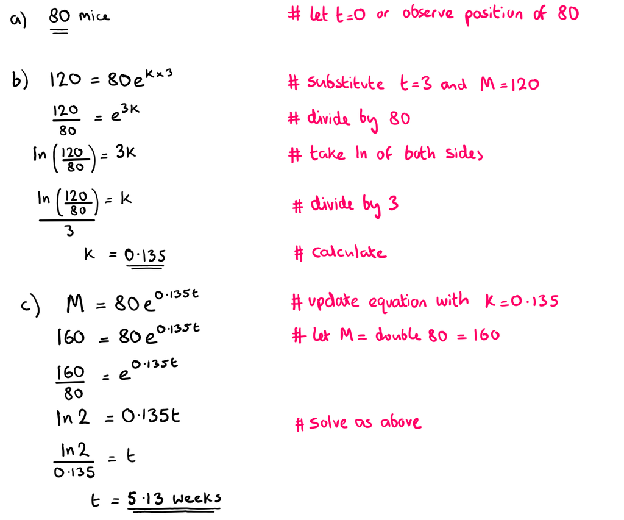

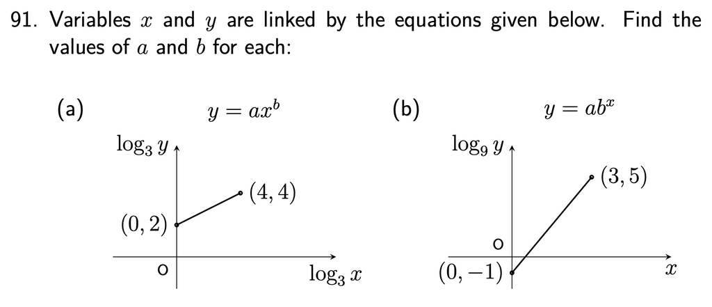

A number of methods may have been taught, so refer to your own notes and examples for *"experimental data"* questions.

1. $a=9$ and $b=\frac{1}{2}$
2. $a=\frac{1}{9}$ and $b=81$

*For more practice, try:* [some of these past exam questions, looking for at least one of each type.](https://www.dynamicmaths.co.uk/QuestionBank/get_questions_handler.php?levelQ=6&otherlevellist=3&how=A&topics%5B%5D=232&orderR=dateA&calc=CN&noQ=500&minmarks=0&maxmarks=999&NR=RO&interleaved=NA&MC=MCA)

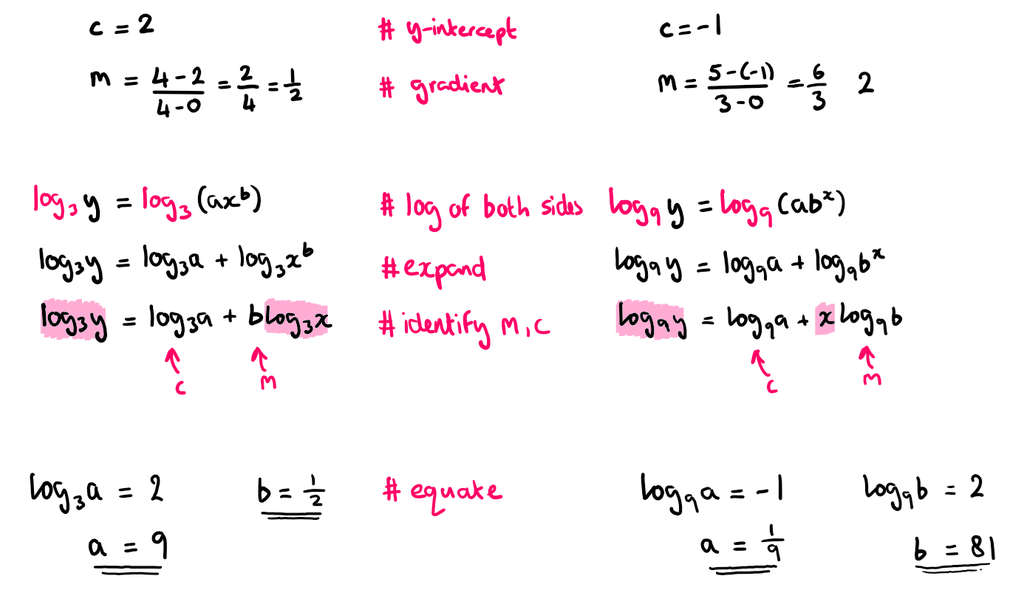

## 16 Further Calculus

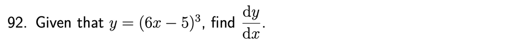

As well a multiplying by the power and reducing the power by one, *what else should you multiply by?*

$\frac{\mathrm{d}y}{\mathrm{d}x}=18(6x-5)^2$

*For more practice, try:* [results 1 and 7 from these past exam questions.](https://www.dynamicmaths.co.uk/QuestionBank/get_questions_handler.php?levelQ=6&otherlevellist=3&how=A&topics%5B%5D=266&orderR=dateA&calc=CN&noQ=500&minmarks=0&maxmarks=999&NR=RO&interleaved=NA&MC=MCA)

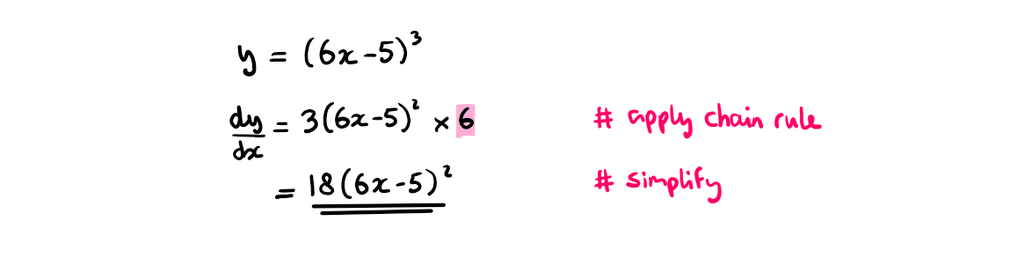

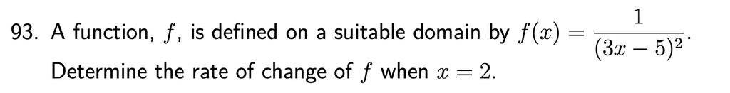

How can this be rewritten in the form $(3x-5)^k$, where $k$ is a (negative in this case) constant.

$-6$

*For more practice, try:* [results 3 and 5 from these past exam questions.](https://www.dynamicmaths.co.uk/QuestionBank/get_questions_handler.php?levelQ=6&otherlevellist=3&how=A&topics%5B%5D=266&orderR=dateA&calc=CN&noQ=500&minmarks=0&maxmarks=999&NR=RO&interleaved=NA&MC=MCA)

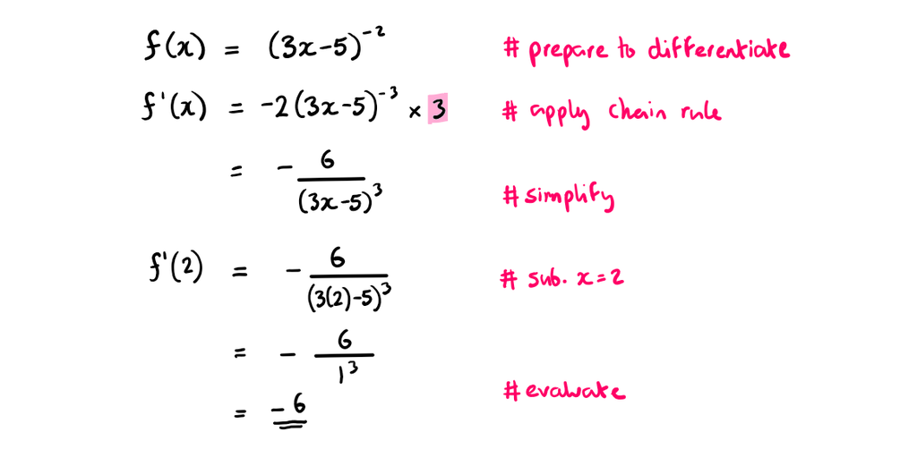

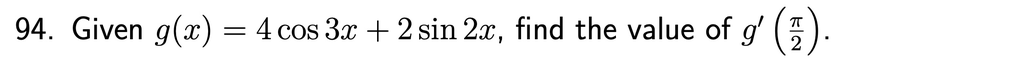

The *formula sheet* contains reminders of how to differentiate trig functions.

$8$

*For more practice, try:* [results 3, 4 and 9 from these past exam questions.](https://www.dynamicmaths.co.uk/QuestionBank/get_questions_handler.php?levelQ=6&otherlevellist=3&how=A&topics%5B%5D=265&orderR=dateA&calc=CN&noQ=500&minmarks=0&maxmarks=999&NR=RO&interleaved=NA&MC=MCA)

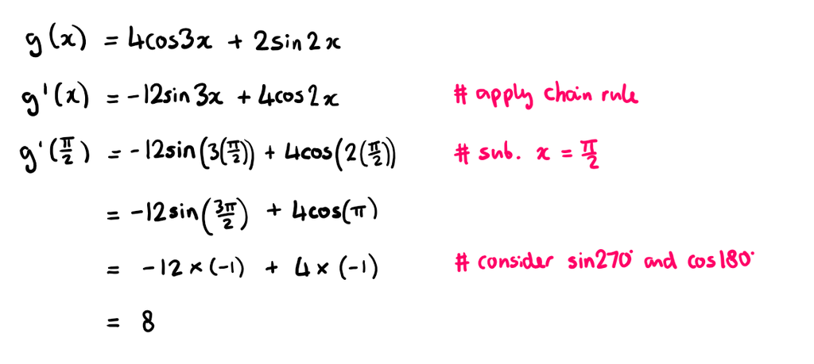

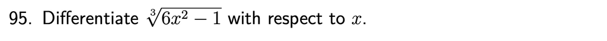

How can this be rewritten in the form $(6x^2-1)^k$, where $k$ is a (fractional in this case) constant.

$4x(6x^2-1)^{-\frac{2}{3}}$

*For more practice, try:* [results 8, 12, 13, 14 and 16 from these past exam questions.](https://www.dynamicmaths.co.uk/QuestionBank/get_questions_handler.php?levelQ=6&otherlevellist=3&how=A&topics%5B%5D=266&orderR=dateA&calc=CN&noQ=500&minmarks=0&maxmarks=999&NR=RO&interleaved=NA&MC=MCA)

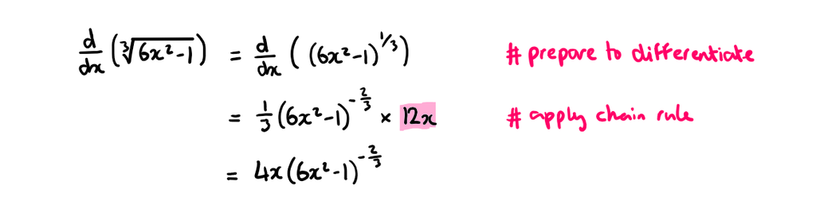

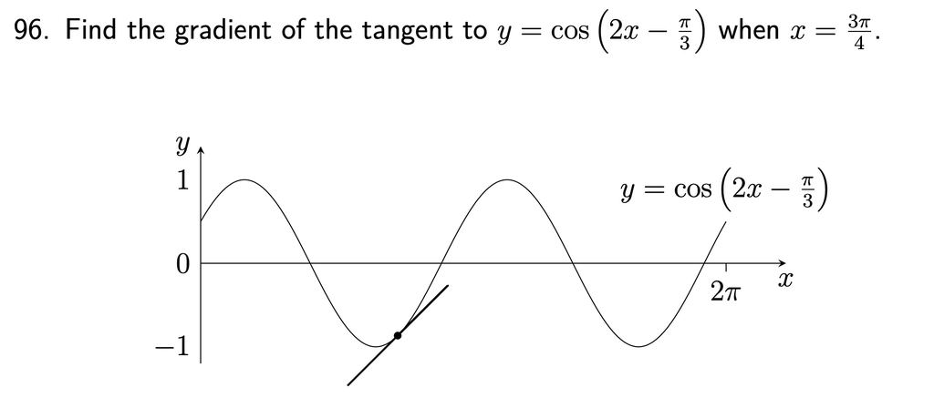

Remember that finding the *gradient of a tangent to a curve* is tackled by first *differentiating*.

$1$

*For more practice, try:* [results 1, 2 and 10 from these past exam questions.](https://www.dynamicmaths.co.uk/QuestionBank/get_questions_handler.php?levelQ=6&otherlevellist=3&how=A&topics%5B%5D=265&orderR=dateA&calc=CN&noQ=500&minmarks=0&maxmarks=999&NR=RO&interleaved=NA&MC=MCA)

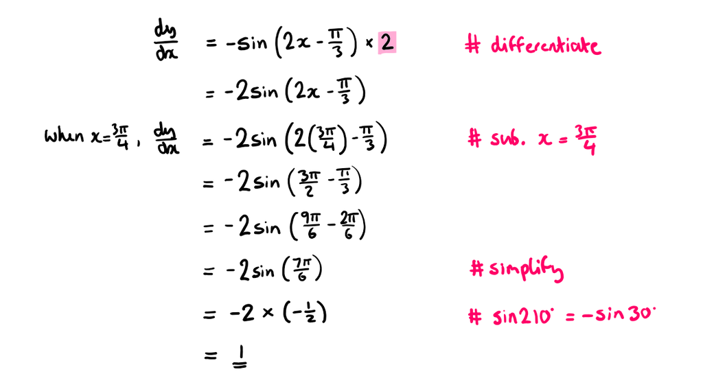

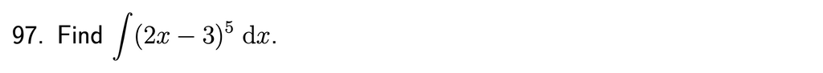

As well as increasing the power by one and dividing by the new power, *what else should you divide by?*

What else should your answer contain, which is easily forgotten?

$\frac{(2x-3)^6}{12}+\mathrm{C}$

*For more practice, try:* [results 1, 3, 5 and 6 from these past exam questions.](https://www.dynamicmaths.co.uk/QuestionBank/get_questions_handler.php?levelQ=6&otherlevellist=3&how=A&topics%5B%5D=275&orderR=dateA&calc=CN&noQ=500&minmarks=0&maxmarks=999&NR=RO&interleaved=NA&MC=MCA)

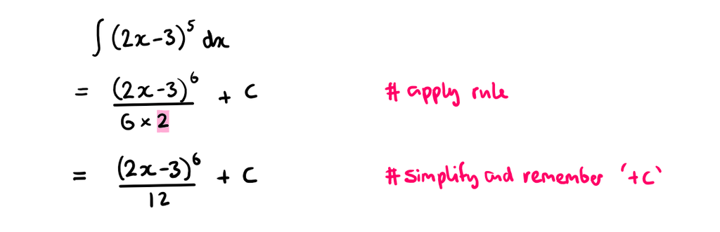

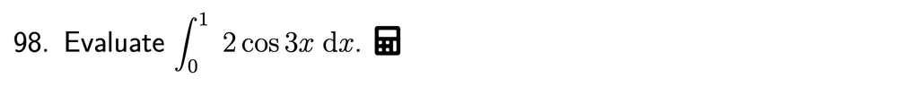

The *formula sheet* gives reminders on integrating trig functions.

Take care with the calculation. Since we are performing *calculus* with *trig functions*, we are working in **radians**.

Put your calculator in a suitable *mode* before the calculation (*and change it straight back afterwards!*).

$0.0941$

*For more practice, try:* [results 4, 5, 10 and 11 and from these past exam questions.](https://www.dynamicmaths.co.uk/QuestionBank/get_questions_handler.php?levelQ=6&otherlevellist=3&how=A&topics%5B%5D=274&orderR=dateA&calc=CN&noQ=500&minmarks=0&maxmarks=999&NR=RO&interleaved=NA&MC=MCA)

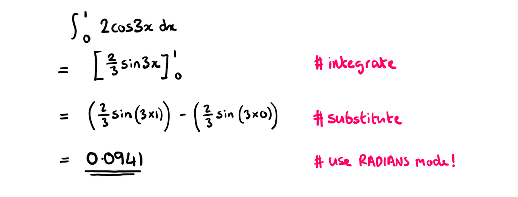

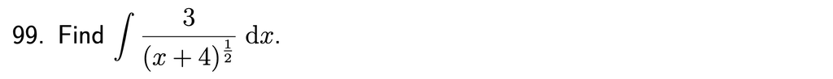

First write this in the form $3(x+4)^k$, where $k$ is a constant.

$6(x+4)^{\frac{1}{2}}+\mathrm{C}$

*For more practice, try:* [results 2, 4, 10 and 11 from these past exam questions.](https://www.dynamicmaths.co.uk/QuestionBank/get_questions_handler.php?levelQ=6&otherlevellist=3&how=A&topics%5B%5D=275&orderR=dateA&calc=CN&noQ=500&minmarks=0&maxmarks=999&NR=RO&interleaved=NA&MC=MCA)

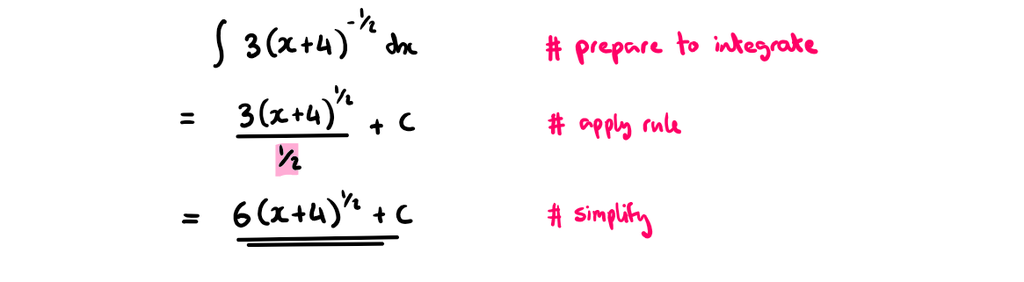

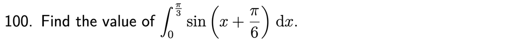

Make sure you can tackle this *without* a calculator.

$\frac{\sqrt{3}}{2}$

*For more practice, try:* [results 2 and 6 from these past exam questions.](https://www.dynamicmaths.co.uk/QuestionBank/get_questions_handler.php?levelQ=6&otherlevellist=3&how=A&topics%5B%5D=274&orderR=dateA&calc=CN&noQ=500&minmarks=0&maxmarks=999&NR=RO&interleaved=NA&MC=MCA)

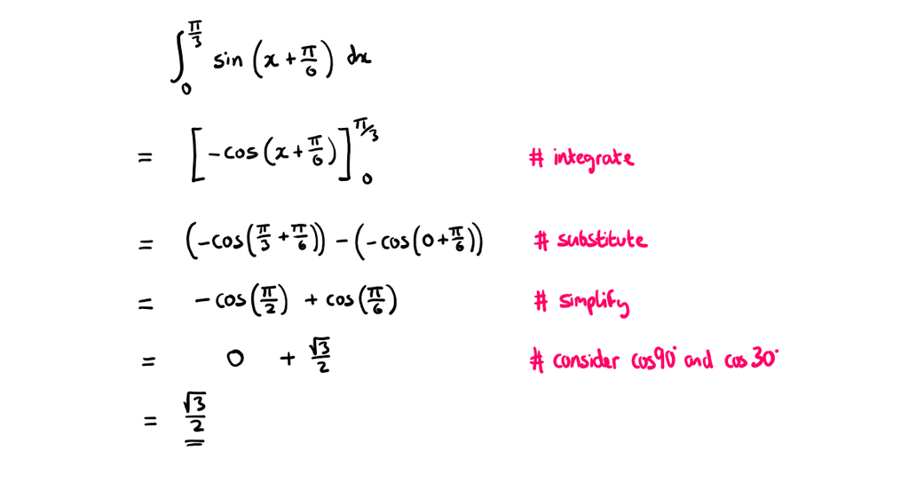